# Univariate TS - real data

Vasja Sivec

# Luxembourg Real GDP Analysis

Previous examples used simulated data, which are well-behaved and simple to model. In this exercise, we will model the quarterly growth of real Gross Domestic Product (rGDP) for Luxembourg — an essential indicator of economic activity. This data presents a greater challenge due to factors like breaks, outliers, measurement errors and difficulty to detect the true model. Additionally, **this data is short which makes tests unreliable**. Nonetheless, those working for statistical offices or finance ministries are tasked with creating forecasts and budget projections utilizing this data.

In April 2022, *Statec* just released the initial estimate of rGDP for 2021Q4 (note that rGDP estimates often undergo revisions). Your objective is to generate rGDP forecasts for 2022Q1 and 2022Q2.

Tasks:

1. Import the Luxembourg rGDP series from an Excel file.
2. Visualize the series and **conduct stationarity tests**.
3. Determine the **suitable ARIMA(p,d,q) model** and assess its characteristics.
4. **Forecast** quarterly rGDP for the next two periods.

# Loading libraries and data

Importing the data and creating a time series object.

```r
library(readxl)
library(ggplot2)
library(stats)
library(forecast)
library(ggpubr)
library(fpp3)
library(aTSA)

# Import data
df <- read_excel('../data/rgdp_2021q4.xlsx')

# Convert it into TS object
y <- ts(df[,"PIB_R_SA"], start=c(sub("*Q.","",df[1,"date"]),sub(".*Q","",df[1,"date"])), frequency=4)
head(y, 12)
```

```
##          Qtr1     Qtr2     Qtr3     Qtr4
## 1995 6788.277 6859.504 6930.816 7005.026
## 1996 7088.155 6590.736 7102.020 7197.751
## 1997 7243.186 7330.884 7414.105 7497.156
```

# Stationary analysis

## ACF and PACF plots

ACF: Autocorrelation Function PACF: Partial Autocorrelation Function

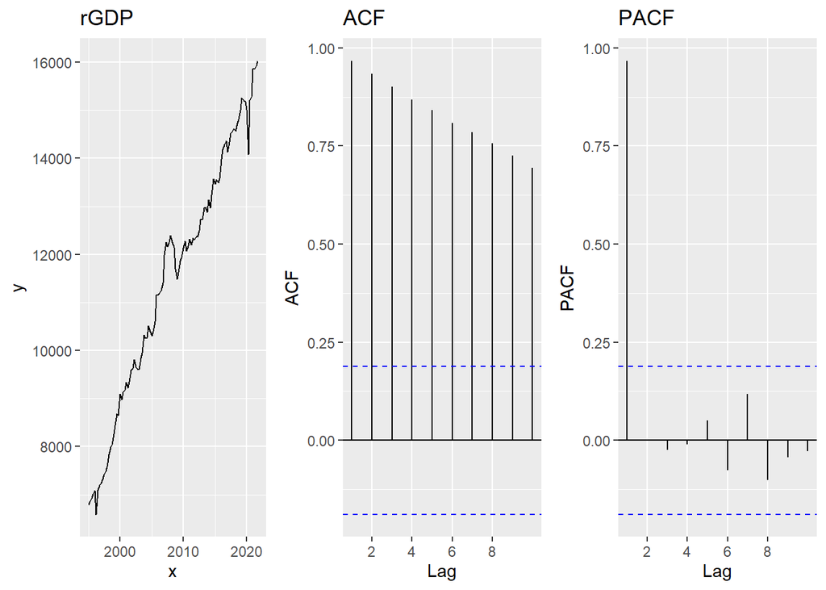

```r
plot_y  <- ggplot(data.frame(x = time(y), y = as.numeric(y)), aes(x = x, y = y)) +
  geom_line() +
  labs(title = "rGDP")

plot_ac  <- ggAcf(y,lag.max = 10) + labs(title="ACF")

plot_pac <- ggPacf(y, lag.max = 10) + labs(title="PACF")

# Display plot
ggarrange(plot_y, plot_ac, plot_pac, ncol = 3)
```

**Question:** Is it stationary or not? why?